# COVID-19 testing в CHOP: факторы положительного теста

Хакатон по биостатистике

Бондаренко Илья

2026-05-25

# 1 Клинический контекст и главный вопрос

Источник-`medicaldata::covid_testing` (Children’s Hospital of Pennsylvania, 2020).

В выборке `n = 15 524` ПЦР-тестов, период соответствует первой волне эпидемии. Госпиталь детский, но тестировались и взрослые.

**Главный вопрос:** Какие факторы связаны с **положительным** результатом теста?

Исследуем бинарный исход → **логистическая регрессия** на полной выборке positive/negative.

# 2 Импорт данных

```r
raw <- read_csv("12_covid_testing_chop.csv", show_col_types = FALSE)
dim(raw)
```

```
## [1] 15524    18
```

Структура таблицы и типы переменных:

```r
glimpse(raw)
```

```
## Rows: 15,524
## Columns: 18
## $ rownames        <dbl> 1, 2, 3, 4, 5, 6, 7, 8, 9, 10, 11, 12, 13, 14, 15, 16,…
## $ subject_id      <dbl> 1412, 533, 9134, 8518, 8967, 11048, 663, 2158, 3794, 4…
## $ fake_first_name <chr> "jhezane", "penny", "grunt", "melisandre", "rolley", "…
## $ fake_last_name  <chr> "westerling", "targaryen", "rivers", "swyft", "karstar…
## $ gender          <chr> "female", "female", "male", "female", "male", "female"…
## $ pan_day         <dbl> 4, 7, 7, 8, 8, 8, 9, 9, 9, 9, 9, 9, 9, 9, 9, 10, 10, 1…
## $ test_id         <chr> "covid", "covid", "covid", "covid", "covid", "covid", …
## $ clinic_name     <chr> "inpatient ward a", "clinical lab", "clinical lab", "c…
## $ result          <chr> "negative", "negative", "negative", "negative", "negat…
## $ demo_group      <chr> "patient", "patient", "patient", "patient", "patient",…
## $ age             <dbl> 0.0, 0.0, 0.8, 0.8, 0.8, 0.8, 0.8, 0.0, 0.0, 0.9, 0.9,…
## $ drive_thru_ind  <dbl> 0, 1, 1, 1, 0, 0, 1, 0, 1, 1, 1, 0, 0, 1, 1, 1, 1, 0, …
## $ ct_result       <dbl> 45, 45, 45, 45, 45, 45, 45, 45, 45, 45, 45, 45, 45, 45…
## $ orderset        <dbl> 0, 0, 1, 1, 1, 0, 1, 1, 1, 1, 0, 1, 0, 1, 1, 1, 1, 1, …
## $ payor_group     <chr> "government", "commercial", NA, NA, "government", "com…
## $ patient_class   <chr> "inpatient", "not applicable", NA, NA, "emergency", "r…
## $ col_rec_tat     <dbl> 1.4, 2.3, 7.3, 5.8, 1.2, 1.4, 2.6, 0.7, 1.0, 7.1, 2.5,…
## $ rec_ver_tat     <dbl> 5.2, 5.8, 4.7, 5.0, 6.4, 7.0, 4.2, 6.3, 5.6, 7.0, 3.8,…
```

```r
summary(raw)
```

```
##     rownames       subject_id     fake_first_name    fake_last_name
##  Min.   :    1   Min.   :    1   Length   :15524   Length   :15524
##  1st Qu.: 3882   1st Qu.: 2330   N.unique :  832   N.unique :   27
##  Median : 7762   Median : 5268   N.blank  :    0   N.blank  :    0
##  Mean   : 7762   Mean   : 5571   Min.nchar:    3   Min.nchar:    4
##  3rd Qu.:11643   3rd Qu.: 8636   Max.nchar:   13   Max.nchar:   11
##  Max.   :15524   Max.   :12346
##
##        gender         pan_day            test_id         clinic_name
##  Length   :15524   Min.   :  4.00   Length   :15524   Length   :15524
##  N.unique :    2   1st Qu.: 38.00   N.unique :    2   N.unique :   88
##  N.blank  :    0   Median : 65.00   N.blank  :    0   N.blank  :    0
##  Min.nchar:    4   Mean   : 63.21   Min.nchar:    5   Min.nchar:    3
##  Max.nchar:    6   3rd Qu.: 87.00   Max.nchar:    5   Max.nchar:   32
##                    Max.   :107.00
##
##        result          demo_group         age         drive_thru_ind
##  Length   :15524   Length   :15524   Min.   :  0.00   Min.   :0.0000
##  N.unique :    3   N.unique :    5   1st Qu.:  2.00   1st Qu.:0.0000
##  N.blank  :    0   N.blank  :    0   Median :  9.00   Median :1.0000
##  Min.nchar:    7   Min.nchar:    6   Mean   : 14.19   Mean   :0.5145
##  Max.nchar:    8   Max.nchar:   12   3rd Qu.: 18.00   3rd Qu.:1.0000
##                                      Max.   :138.00   Max.   :1.0000
##
##    ct_result        orderset         payor_group      patient_class
##  Min.   :14.05   Min.   :0.0000   Length   :15524   Length   :15524
##  1st Qu.:45.00   1st Qu.:0.0000   N.unique :    7   N.unique :    9
##  Median :45.00   Median :1.0000   N.blank  :    0   N.blank  :    0
##  Mean   :44.12   Mean   :0.6952   Min.nchar:    5   Min.nchar:    9
##  3rd Qu.:45.00   3rd Qu.:1.0000   Max.nchar:   18   Max.nchar:   23
##  Max.   :45.00   Max.   :1.0000   NAs      : 7087   NAs      : 7077
##  NAs    :209
##   col_rec_tat         rec_ver_tat
##  Min.   :    0.000   Min.   :-18.600
##  1st Qu.:    0.700   1st Qu.:  4.000
##  Median :    1.900   Median :  5.000
##  Mean   :    7.221   Mean   :  5.639
##  3rd Qu.:    3.600   3rd Qu.:  6.200
##  Max.   :61370.200   Max.   :218.200
##
```

# 3 Подготовка данных

Видим, что есть неадекватные значения в колонке `age`, т.к. есть человек, которому 138 лет. В реальности же, самому большому долгожителю Земли, из всех живущих, было 122 года. (Также есть отрицательные значения времени в колонке `rec_ver_tat`, которая означает время от получения теста до верификации, но ее мы не используем в нашей модели). Возраст в 0 лет мы считаем адекватным, т.к. эта детская больница и тест могли делать новорожденным.

```r
# Посмотрим, сколько в нашем датасете тех, кому больше 100 лет.
raw |>
  filter(age > 100) |>
  select(subject_id, age, demo_group, patient_class) |>
  arrange(desc(age))
```

| subject_id | age | demo_group | patient_class |
| --- | --- | --- | --- |
| 3049 | 138 | client | NA |
| 4078 | 119 | patient | inpatient |
| 12293 | 119 | other adult | emergency |
| 11177 | 119 | client | NA |
| 337 | 119 | misc adult | inpatient |

```r
# Наблюдения с возрастом >100 лет были расценены как вероятные ошибки ввода и исключены из анализа.
n_before <- nrow(raw)

raw <- raw |>
  filter(age <= 100)

cat("Было:      ", n_before, "\n")
```

```
## Было:       15524
```

```r
cat("Осталось:  ", nrow(raw), "\n")
```

```
## Осталось:   15519
```

```r
cat("Исключено: ", n_before - nrow(raw), "\n")
```

```
## Исключено:  5
```

Пропуски по колонкам:

```r
miss_tbl <- raw |>
  summarise(across(everything(), ~ sum(is.na(.x)))) |>
  pivot_longer(everything(), names_to = "var", values_to = "n_missing") |>
  mutate(pct = round(100 * n_missing / nrow(raw), 1)) |>
  arrange(desc(pct))
miss_tbl
```

| var | n_missing | pct |
| --- | --- | --- |
| payor_group | 7085 | 45.7 |
| patient_class | 7075 | 45.6 |
| ct_result | 209 | 1.3 |
| rownames | 0 | 0.0 |
| subject_id | 0 | 0.0 |
| fake_first_name | 0 | 0.0 |
| fake_last_name | 0 | 0.0 |
| gender | 0 | 0.0 |
| pan_day | 0 | 0.0 |
| test_id | 0 | 0.0 |
| clinic_name | 0 | 0.0 |
| result | 0 | 0.0 |
| demo_group | 0 | 0.0 |
| age | 0 | 0.0 |
| drive_thru_ind | 0 | 0.0 |
| orderset | 0 | 0.0 |
| col_rec_tat | 0 | 0.0 |
| rec_ver_tat | 0 | 0.0 |

- `result` имеет 3 уровня (negative / positive / invalid). Оставляем только positive vs negative - это корректные исходы.
- `patient_class` и `payor_group` пропущены у ~46%. Пропуски кодируем отдельным уровнем `missing`, чтобы не терять половину выборки.
- `ct_result` пропущен у 209 - не используем как предиктор (он практически зеркало `result`, т.к. оно показывает кол-ва вируса в человеке).

Проверяем сколько тестов, которые делал один человек

```r
raw |>
  count(subject_id) |>
  count(n, name = "n_patients") |>
  rename(n_tests = n) |>
  mutate(pct = round(100 * n_patients / sum(n_patients), 1))
```

| n_tests | n_patients | pct |
| --- | --- | --- |
| 1 | 10595 | 85.9 |
| 2 | 1131 | 9.2 |
| 3 | 290 | 2.4 |
| 4 | 141 | 1.1 |
| 5 | 71 | 0.6 |
| 6 | 42 | 0.3 |
| 7 | 28 | 0.2 |
| 8 | 19 | 0.2 |
| 9 | 7 | 0.1 |
| 10 | 3 | 0.0 |
| 11 | 1 | 0.0 |
| 12 | 2 | 0.0 |
| 13 | 1 | 0.0 |
| 14 | 2 | 0.0 |
| 15 | 2 | 0.0 |
| 16 | 1 | 0.0 |
| 18 | 1 | 0.0 |
| 20 | 2 | 0.0 |

Получилось, что более 14 процентов датасета это не независимые записи - это тесты, которые делали одни и те же люди. Будем считать, что тест, сделанный как минимум через месяц после предыдущего, является независимым.

```r
df_independent <- raw |>
  arrange(subject_id, pan_day) |>
  group_by(subject_id) |>
  filter(pan_day - lag(pan_day, default = -31) >= 30) |>  # разница >= 30 дней
  ungroup()

cat("Исходно тестов:   ", nrow(raw), "\n")
```

```
## Исходно тестов:    15519
```

```r
cat("После фильтрации: ", nrow(df_independent), "\n")
```

```
## После фильтрации:  13241
```

```r
cat("Выброшено:        ", nrow(raw) - nrow(df_independent), "\n")
```

```
## Выброшено:         2278
```

Если вывести категории `patient_class` и `payor_group`, можно увидеть, что подгруппы, в которых менее 100 человек, носят в основном административный характер (либо слишком маленькие для стат. выводов), и их можно объединить в одну группу, чтобы не терять данные. В случае 1 кейса `unidentified` в `demo_group` от него мы просто избавляемся.

```r
raw |> count(demo_group) |> arrange(n)
```

| demo_group | n |
| --- | --- |
| unidentified | 1 |
| other adult | 222 |
| client | 602 |
| misc adult | 2440 |
| patient | 12254 |

```r
raw |> count(patient_class) |> arrange(n)
```

| patient_class | n |
| --- | --- |
| admit after surgery-obs | 1 |
| admit after surgery-ip | 4 |
| day surgery | 39 |
| observation | 723 |
| recurring outpatient | 795 |
| outpatient | 973 |
| not applicable | 1096 |
| emergency | 1377 |
| inpatient | 3436 |
| NA | 7075 |

```r
raw |> count(payor_group) |> arrange(n)
```

| payor_group | n |
| --- | --- |
| charity care | 15 |
| other | 19 |
| medical assistance | 84 |
| self pay | 216 |
| unassigned | 733 |
| government | 3643 |
| commercial | 3724 |
| NA | 7085 |

```r
df_logit <- df_independent |>
  # исключаем invalid: не клинический исход
  filter(result %in% c("positive", "negative")) |>
  filter(demo_group != "unidentified") |>
  mutate(
    positive   = as.integer(result == "positive"),
    gender     = factor(gender, levels = c("female", "male")),
    drive_thru = factor(drive_thru_ind, levels = c(0, 1),
                        labels = c("clinic", "drive_thru")),
    orderset   = factor(orderset, levels = c(0, 1),
                        labels = c("no_orderset", "orderset")),

    # Из-за высокой доли пропусков удаление наблюдений могло привести к существенной потере мощности исследования, поэтому пропуски были выделены в отдельную категорию, поэтому пропуски идут в отдельную категорию missing.

    patient_class = factor(if_else(is.na(patient_class), "patient_class_missing", patient_class)),
    payor_group   = factor(if_else(is.na(payor_group),   "payor_group_missing", payor_group)),

    # редкие уровни (<100 наблюдений) схлопываем в "other";
    patient_class = fct_lump_min(patient_class, min = 100, other_level = "other_patient_class"),
    payor_group    = fct_lump_min(factor(payor_group), min = 100, other_level = "other_payor_group")
  ) |>
  #  reference levels-клинически интерпретируемые
  mutate(
    demo_group    = fct_relevel(demo_group,    "patient"),
    patient_class = fct_relevel(patient_class, "outpatient"),
    drive_thru    = fct_relevel(drive_thru,    "clinic"),
    orderset      = fct_relevel(orderset,      "no_orderset"),
    payor_group   = fct_relevel(payor_group,   "commercial")
  )
# Референс outpatient выбран как клинически интерпретируемая группа, несмотря на то что наиболее частой категорией является missing (45%).

cat("df_logit:", nrow(df_logit), "тестов;",
    sum(df_logit$positive), "positive",
    sprintf("(%.2f%%)\n", 100 * mean(df_logit$positive)))
```

```
## df_logit: 13083 тестов; 777 positive (5.94%)
```

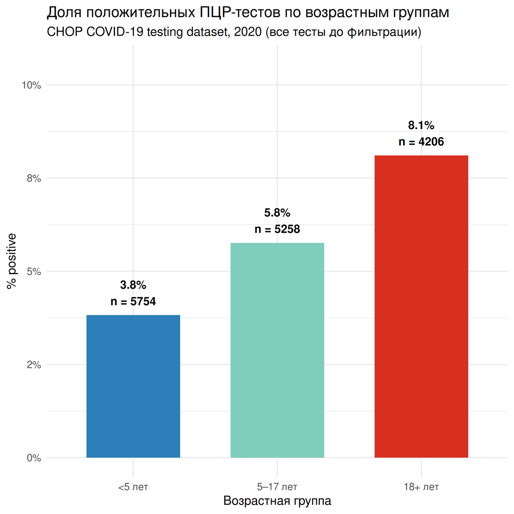

```r
age_group_plot <- raw |>
  filter(result %in% c("positive", "negative")) |>
  mutate(
    positive  = as.integer(result == "positive"),
    age_group = case_when(
      age < 5            ~ "<5 лет",
      age >= 5 & age < 18 ~ "5–17 лет",
      age >= 18           ~ "18+ лет",
      TRUE               ~ NA_character_
    ),
    age_group = factor(age_group, levels = c("<5 лет", "5–17 лет", "18+ лет"))
  ) |>
  group_by(age_group) |>
  summarise(
    n_tests      = n(),
    n_positive   = sum(positive, na.rm = TRUE),
    pct_positive = n_positive / n_tests,
    .groups = "drop"
  )

ggplot(age_group_plot, aes(x = age_group, y = pct_positive, fill = age_group)) +
  geom_col(width = 0.65) +
  geom_text(
    aes(label = paste0(percent(pct_positive, accuracy = 0.1), "\nn = ", n_tests)),
    vjust = -0.4,
    size  = 4.5,
    fontface = "bold"
  ) +
  scale_fill_manual(values = c(
    "<5 лет"   = "#2c7fb8",
    "5–17 лет" = "#7fcdbb",
    "18+ лет"  = "#d7301f"
  )) +
  scale_y_continuous(
    labels = percent_format(accuracy = 1),
    limits = c(0, max(age_group_plot$pct_positive) * 1.3)
  ) +
  labs(
    title    = "Доля положительных ПЦР-тестов по возрастным группам",
    subtitle = "CHOP COVID-19 testing dataset, 2020 (все тесты до фильтрации)",
    x        = "Возрастная группа",
    y        = "% positive"
  ) +
  theme_minimal(base_size = 14) +
  theme(legend.position = "none")
```

**Reference levels** заданы явно:

- `demo_group = patient`-основная клиническая группа (пациенты CHOP).
- `patient_class = outpatient`-типичный амбулаторный визит.
- `drive_thru = clinic`-забор внутри клиники.
- `orderset = no_orderset`-без стандартизованного протокола.
- `payor_group = commercial`-частая страховка.
- `gender = female`-по умолчанию.

Все коэффициенты регрессии будут читаться **относительно этих уровней**.

# 4 Описательная статистика

Считаем таблицу для каждой переменной: сколько всего, сколько positive, какая доля positive.

## 4.1 Числовые переменные (возраст)

```r
df_logit |>
  group_by(result) |>
  summarise(n          = n(),
            age_mean   = round(mean(age), 1),
            age_sd     = round(sd(age),   1),
            age_median = median(age))
```

| result | n | age_mean | age_sd | age_median |
| --- | --- | --- | --- | --- |
| negative | 12306 | 14.8 | 16.5 | 10 |
| positive | 777 | 19.2 | 18.2 | 15 |

## 4.2 Доля positive по полу

```r
df_logit |>
  group_by(gender) |>
  summarise(n            = n(),
            n_pos        = sum(positive),
            pct_positive = round(100 * mean(positive), 2))
```

| gender | n | n_pos | pct_positive |
| --- | --- | --- | --- |
| female | 6611 | 408 | 6.17 |
| male | 6472 | 369 | 5.70 |

## 4.3 Доля positive по demo_group

```r
df_logit |>
  group_by(demo_group) |>
  summarise(n            = n(),
            n_pos        = sum(positive),
            pct_positive = round(100 * mean(positive), 2))
```

| demo_group | n | n_pos | pct_positive |
| --- | --- | --- | --- |
| patient | 10117 | 475 | 4.70 |
| client | 551 | 76 | 13.79 |
| misc adult | 2210 | 219 | 9.91 |
| other adult | 205 | 7 | 3.41 |

## 4.4 Доля positive по patient_class

```r
df_logit |>
  group_by(patient_class) |>
  summarise(n            = n(),
            n_pos        = sum(positive),
            pct_positive = round(100 * mean(positive), 2))
```

| patient_class | n | n_pos | pct_positive |
| --- | --- | --- | --- |
| outpatient | 866 | 58 | 6.70 |
| emergency | 1284 | 124 | 9.66 |
| inpatient | 2245 | 65 | 2.90 |
| not applicable | 971 | 49 | 5.05 |
| observation | 606 | 14 | 2.31 |
| patient_class_missing | 6718 | 457 | 6.80 |
| recurring outpatient | 352 | 8 | 2.27 |
| other_patient_class | 41 | 2 | 4.88 |

## 4.5 Доля positive по drive_thru

```r
df_logit |>
  group_by(drive_thru) |>
  summarise(n            = n(),
            n_pos        = sum(positive),
            pct_positive = round(100 * mean(positive), 2))
```

| drive_thru | n | n_pos | pct_positive |
| --- | --- | --- | --- |
| clinic | 5879 | 331 | 5.63 |
| drive_thru | 7204 | 446 | 6.19 |

## 4.6 Доля positive по orderset

```r
df_logit |>
  group_by(orderset) |>
  summarise(n            = n(),
            n_pos        = sum(positive),
            pct_positive = round(100 * mean(positive), 2))
```

| orderset | n | n_pos | pct_positive |
| --- | --- | --- | --- |
| no_orderset | 3304 | 140 | 4.24 |
| orderset | 9779 | 637 | 6.51 |

```r
make_num_row <- function(df, var, label) {
  df |>
    group_by(result) |>
    summarise(
      val = sprintf("%.0f (%.0f–%.0f)",
                    median(.data[[var]], na.rm = TRUE),
                    quantile(.data[[var]], 0.25, na.rm = TRUE),
                    quantile(.data[[var]], 0.75, na.rm = TRUE)),
      .groups = "drop"
    ) |>
    pivot_wider(names_from = result, values_from = val) |>
    mutate(variable = label) |>
    select(variable, negative, positive)
}

make_cat_rows <- function(df, var, label) {
  df |>
    group_by(result, level = .data[[var]]) |>
    summarise(n = n(), .groups = "drop") |>
    group_by(result) |>
    mutate(pct  = round(100 * n / sum(n), 1),
           val  = sprintf("%d (%.1f%%)", n, pct)) |>
    ungroup() |>
    select(result, level, val) |>
    pivot_wider(names_from = result, values_from = val) |>
    mutate(variable = paste0(label, ": ", level)) |>
    select(variable, negative, positive)
}

n_neg <- sum(df_logit$result == "negative")
n_pos <- sum(df_logit$result == "positive")

table1 <- bind_rows(
  make_num_row(df_logit, "age",     "Age, median (IQR)"),
  make_num_row(df_logit, "pan_day", "Pan day, median (IQR)"),
  make_cat_rows(df_logit, "gender",        "Gender"),
  make_cat_rows(df_logit, "demo_group",    "Demo group"),
  make_cat_rows(df_logit, "patient_class", "Patient class"),
  make_cat_rows(df_logit, "drive_thru",    "Drive-thru"),
  make_cat_rows(df_logit, "orderset",      "Orderset"),
  make_cat_rows(df_logit, "payor_group",   "Payor group")
)

table1 |>
  knitr::kable(
    col.names = c("Variable",
                  sprintf("Negative (n=%d)", n_neg),
                  sprintf("Positive (n=%d)", n_pos)),
    align = c("l", "r", "r"),
    caption = "Table 1. Baseline characteristics by COVID-19 test result"
  )
```

Table 1. Baseline characteristics by COVID-19 test result

| Variable | Negative (n=12306) | Positive (n=777) |
| --- | --- | --- |
| Age, median (IQR) | 10 (2–19) | 15 (5–27) |
| Pan day, median (IQR) | 64 (37–86) | 63 (38–86) |
| Gender: female | 6203 (50.4%) | 408 (52.5%) |
| Gender: male | 6103 (49.6%) | 369 (47.5%) |
| Demo group: patient | 9642 (78.4%) | 475 (61.1%) |
| Demo group: client | 475 (3.9%) | 76 (9.8%) |
| Demo group: misc adult | 1991 (16.2%) | 219 (28.2%) |
| Demo group: other adult | 198 (1.6%) | 7 (0.9%) |
| Patient class: outpatient | 808 (6.6%) | 58 (7.5%) |
| Patient class: emergency | 1160 (9.4%) | 124 (16.0%) |
| Patient class: inpatient | 2180 (17.7%) | 65 (8.4%) |
| Patient class: not applicable | 922 (7.5%) | 49 (6.3%) |
| Patient class: observation | 592 (4.8%) | 14 (1.8%) |
| Patient class: patient_class_missing | 6261 (50.9%) | 457 (58.8%) |
| Patient class: recurring outpatient | 344 (2.8%) | 8 (1.0%) |
| Patient class: other_patient_class | 39 (0.3%) | 2 (0.3%) |
| Drive-thru: clinic | 5548 (45.1%) | 331 (42.6%) |
| Drive-thru: drive_thru | 6758 (54.9%) | 446 (57.4%) |
| Orderset: no_orderset | 3164 (25.7%) | 140 (18.0%) |
| Orderset: orderset | 9142 (74.3%) | 637 (82.0%) |
| Payor group: commercial | 2623 (21.3%) | 77 (9.9%) |
| Payor group: government | 2518 (20.5%) | 189 (24.3%) |
| Payor group: payor_group_missing | 6265 (50.9%) | 457 (58.8%) |
| Payor group: self pay | 183 (1.5%) | 10 (1.3%) |
| Payor group: unassigned | 617 (5.0%) | 39 (5.0%) |
| Payor group: other_payor_group | 100 (0.8%) | 5 (0.6%) |

[figure not shown]

```r
vars_to_plot <- list(
  gender        = "Gender",
  demo_group    = "Demo group",
  patient_class = "Patient class",
  drive_thru    = "Drive-thru",
  orderset      = "Orderset",
  payor_group   = "Payor group"
)

plot_data <- map2(names(vars_to_plot), vars_to_plot, function(var, label) {
  df_logit |>
    group_by(result, level = .data[[var]]) |>
    summarise(n = n(), .groups = "drop") |>
    group_by(result) |>
    mutate(pct = 100 * n / sum(n)) |>
    ungroup() |>
    mutate(variable = label,
           level = as.character(level))
}) |>
  bind_rows()

ggplot(plot_data, aes(x = fct_reorder(level, pct), y = pct, fill = result)) +
  geom_col(position = "dodge") +
  scale_fill_manual(values = c("negative" = "#2c7fb8", "positive" = "#d7301f"),
                    name = NULL) +
  facet_wrap(~ variable, scales = "free_x", ncol = 2) +
  labs(x = NULL, y = "%",
       caption = "Группы с n < 100 не показаны") +
  theme_minimal() +
  theme(
    strip.text = element_text(face = "bold"),
    axis.text.x = element_text(angle = 45, hjust = 1),
    legend.position = "top"
  )
```

# 5 Графики

## 5.1 График 1. Возраст по исходу

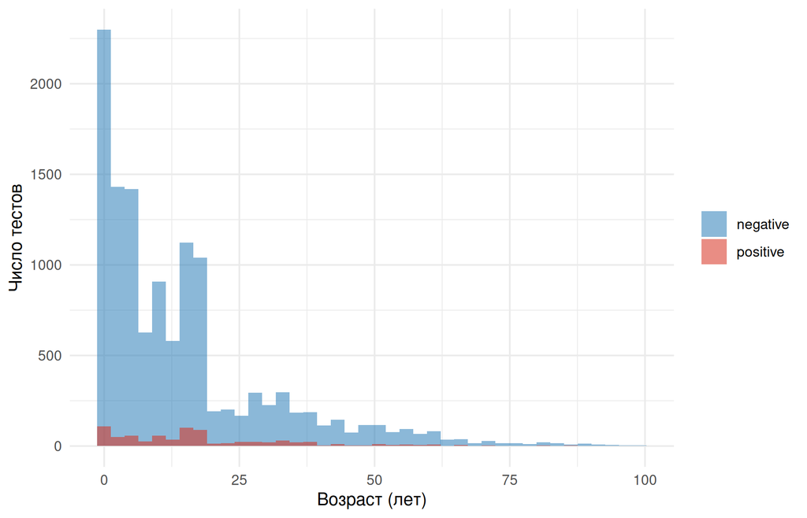

Распределение возраста: positive vs negative

```r
ggplot(df_logit, aes(age, fill = factor(positive))) +
  geom_histogram(bins = 40, position = "identity", alpha = 0.55) +
  scale_fill_manual(values = c("0" = "#2c7fb8", "1" = "#d7301f"),
                    labels = c("negative", "positive"), name = NULL) +
  labs(x = "Возраст (лет)", y = "Число тестов") +
  theme_minimal()
```

### 5.1.1 Положительность по возрастным группам

```r
df_logit |>
  mutate(age_group = cut(age,
                         breaks = c(0, 5, 18, Inf),
                         labels = c("< 5 (раннее детство)",
                                    "5-17 (школьники/подростки)",
                                    "18+ (взрослые)"),
                         right = FALSE,
                         include.lowest = TRUE)) |>
  group_by(age_group) |>
  summarise(n            = n(),
            n_pos        = sum(positive),
            pct_positive = round(100 * mean(positive), 2))
```

| age_group | n | n_pos | pct_positive |
| --- | --- | --- | --- |
| < 5 (раннее детство) | 4462 | 181 | 4.06 |
| 5-17 (школьники/подростки) | 4801 | 283 | 5.89 |
| 18+ (взрослые) | 3820 | 313 | 8.19 |

Большинство тестов сделано у детей (CHOP - детский госпиталь). Доля positive выше у взрослых. Это может отражать то, что взрослые тестируемые представляют другую группу по составу и показаниям к тестированию

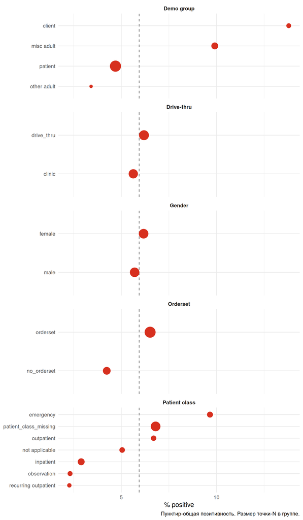

```r
# Считаем pct_positive для каждой переменной/уровня
vars_to_plot <- list(
  gender        = "Gender",
  demo_group    = "Demo group",
  patient_class = "Patient class",
  drive_thru    = "Drive-thru",
  orderset      = "Orderset"
)

plot_data <- map2(names(vars_to_plot), vars_to_plot, function(var, label) {
  df_logit |>
    group_by(level = .data[[var]]) |>
    summarise(
      n            = n(),
      pct_positive = 100 * mean(positive),
      .groups = "drop"
    ) |>
    filter(n >= 100) |>  # убираем маленькие группы
    mutate(variable = label,
           level    = paste0(level))
}) |>
  bind_rows()

ggplot(plot_data, aes(x = pct_positive, y = fct_reorder(level, pct_positive))) +
  geom_vline(xintercept = 100 * mean(df_logit$positive),
             linetype = "dashed", colour = "grey50") +
  geom_point(aes(size = n), colour = "#d7301f") +
  scale_size_continuous(range = c(2, 8), guide = "none") +
  facet_wrap(~ variable, scales = "free_y", ncol = 1) +
  labs(
    x = "% positive",
    y = NULL,
    caption = "Пунктир-общая позитивность. Размер точки-N в группе."
  ) +
  theme_minimal() +
  theme(strip.text = element_text(face = "bold"))
```

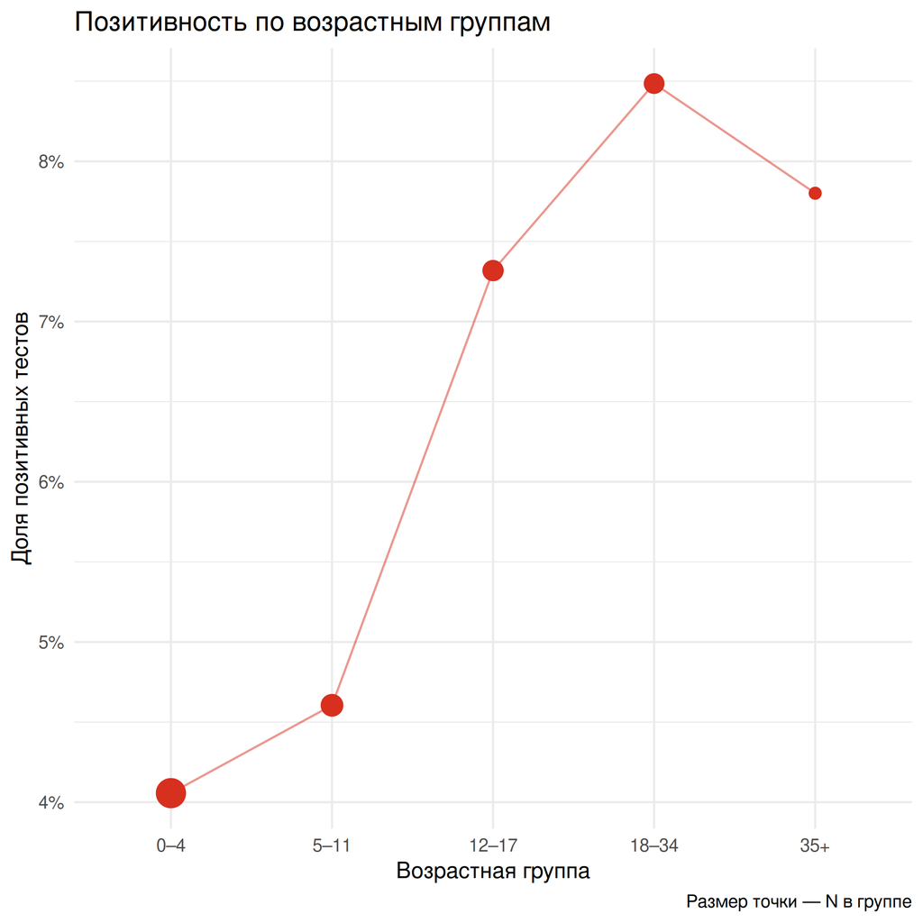

```r
age_positivity <- df_logit |>
  mutate(
    age_group = cut(age,
                    breaks = c(0, 5, 12, 18, 35, Inf),
                    labels = c("0–4", "5–11", "12–17", "18–34", "35+"),
                    right  = FALSE,
                    include.lowest = TRUE)
  ) |>
  group_by(age_group) |>
  summarise(
    n            = n(),
    n_pos        = sum(positive),
    pct_positive = mean(positive),
    .groups = "drop"
  )

ggplot(age_positivity, aes(x = age_group, y = pct_positive)) +
  geom_point(aes(size = n), colour = "#d7301f") +
  geom_line(aes(group = 1), colour = "#d7301f", alpha = 0.5) +
  scale_y_continuous(labels = percent_format(accuracy = 1)) +
  scale_size_continuous(range = c(3, 8), guide = "none") +
  labs(
    x       = "Возрастная группа",
    y       = "Доля позитивных тестов",
    title   = "Позитивность по возрастным группам",
    caption = "Размер точки — N в группе"
  ) +
  theme_minimal(base_size = 14)
```

График наблюдаемой позитивности по возрастным группам показывает нелинейную связь - позитивность растёт от детей до взрослых 18–34 лет, затем снижается в группе 35+.

Как и график зависимости позитивности от дня пандемии:

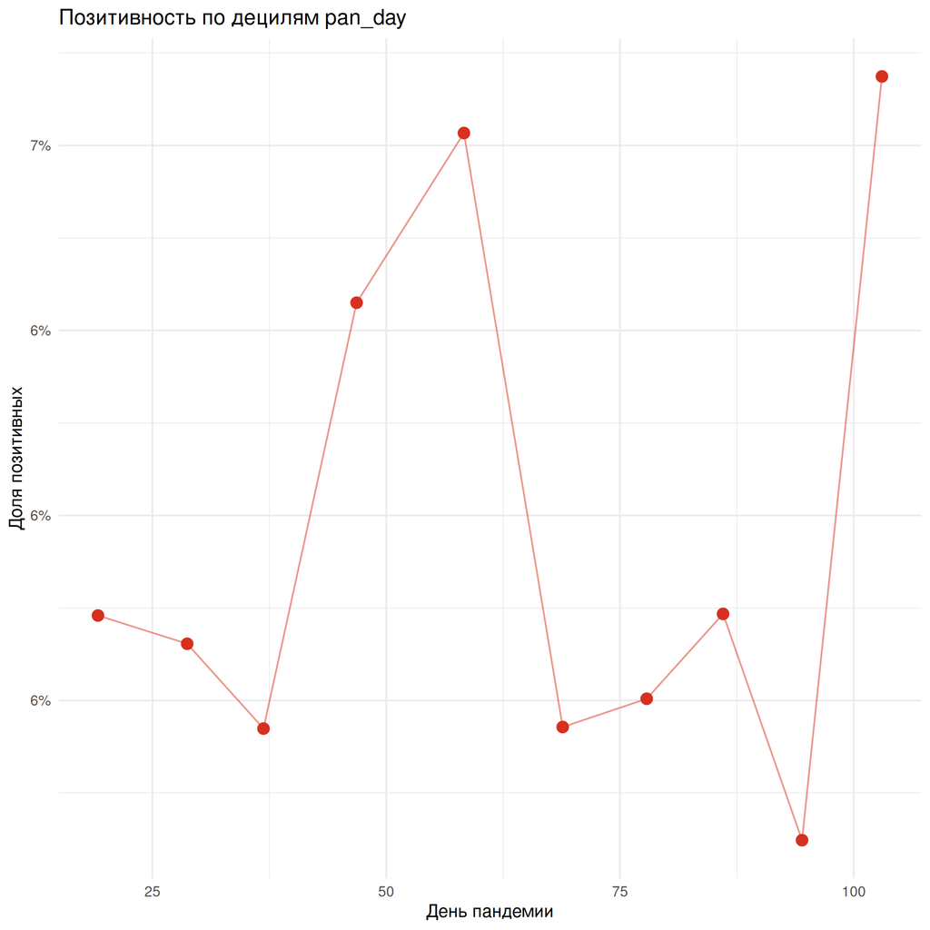

```r
pan_day_risk <- df_logit |>
  mutate(decile = ntile(pan_day, 10)) |>
  group_by(decile) |>
  summarise(
    mean_pan_day     = mean(pan_day),
    observed_risk    = mean(positive),
    .groups = "drop"
  )

ggplot(pan_day_risk, aes(x = mean_pan_day, y = observed_risk)) +
  geom_point(colour = "#d7301f", size = 3) +
  geom_line(colour = "#d7301f", alpha = 0.5) +
  scale_y_continuous(labels = percent_format(accuracy = 1)) +
  labs(x = "День пандемии", y = "Доля позитивных",
       title = "Позитивность по децилям pan_day") +
  theme_minimal()
```

# 6 Основной анализ. Логистическая регрессия positivity

## 6.1 Почему логистическая

Исход бинарный (positive / negative). Линейная регрессия на 0/1 непригодна: предсказанные значения могут уйти за `[0, 1]`, а ошибки негомоскедастичны.

Экспоненцирование коэффициента даёт **odds ratio** (OR).

## 6.2 Число событий и не-событий

```r
events     <- sum(df_logit$positive)
non_events <- nrow(df_logit) - events
c(events = events, non_events = non_events)
```

```
##     events non_events
##        777      12306
```

## 6.3 Попарная корреляция

```r
# Для категориальных-таблица Крамера V

cat_vars <- c("gender", "demo_group", "patient_class",
              "drive_thru", "payor_group", "orderset")

# Все попарные комбинации
combn(cat_vars, 2, simplify = FALSE) |>
  map_dfr(function(pair) {
    tbl <- table(df_logit[[pair[1]]], df_logit[[pair[2]]])
    v   <- cramer_v(tbl)
    tibble(var1 = pair[1], var2 = pair[2], cramer_v = round(v, 3))
  }) |>
  arrange(desc(cramer_v))
```

| var1 | var2 | cramer_v |
| --- | --- | --- |
| drive_thru | payor_group | 0.838 |
| patient_class | drive_thru | 0.834 |
| patient_class | orderset | 0.832 |
| payor_group | orderset | 0.660 |
| patient_class | payor_group | 0.604 |
| demo_group | drive_thru | 0.437 |
| demo_group | payor_group | 0.365 |
| drive_thru | orderset | 0.319 |
| demo_group | patient_class | 0.283 |
| demo_group | orderset | 0.231 |
| gender | demo_group | 0.018 |
| gender | payor_group | 0.018 |
| gender | patient_class | 0.013 |
| gender | orderset | 0.004 |
| gender | drive_thru | 0.003 |

После проверки попарной корреляции (Cramer’s V) будут исключены из модели `patient_class` и `payor_group`-46% пропусков и V > 0.6 с оставшимися предикторами. Максимальная корреляция в итоговой модели-V = 0.44 (`demo_group` - `drive_thru`), что находится в допустимых пределах

```r
cor.test(df_logit$age, df_logit$pan_day, method = "spearman")
```

```
##
##  Spearman's rank correlation rho
##
## data:  df_logit$age and df_logit$pan_day
## S = 2.3119e+11, p-value < 2.2e-16
## alternative hypothesis: true rho is not equal to 0
## sample estimates:
##       rho
## 0.3805702
```

Допустимая корреляция, все ок.

```r
# eta squared - аналог Cramer V для числовая vs категориальная
cat_vars <- c("gender", "demo_group", "drive_thru", "orderset")

map_dfr(cat_vars, function(var) {
  tibble(
    var1 = "age",
    var2 = var,
    eta  = round(sqrt(summary(aov(age ~ df_logit[[var]], data = df_logit))[[1]][1,2] /
                      sum(summary(aov(age ~ df_logit[[var]], data = df_logit))[[1]][,2])), 3)
  )
})
```

| var1 | var2 | eta |
| --- | --- | --- |
| age | gender | 0.002 |
| age | demo_group | 0.791 |
| age | drive_thru | 0.165 |
| age | orderset | 0.162 |

Получается, что `demo_group` почти полностью отражает `age`, что логично - `misc adult` и `client` это взрослые, `patient` это в основном дети. Уберем из модели `demo_group`.

```r
df_logit <- df_logit |>
  mutate(
    age_group4 = cut(age,
                     breaks = c(0, 12, 18, 35, Inf),
                     labels = c("0–11", "12–17", "18–34", "35+"),
                     right  = FALSE,
                     include.lowest = TRUE),
    age_group4 = factor(age_group4,
                        levels = c("0–11", "12–17", "18–34", "35+"))
  )

m_discrete <- glm(  # модель, где возраст дискретизировали в 4 группы
  positive ~ age_group4 + gender + drive_thru + orderset + pan_day,
  data = df_logit, family = binomial()
)

m_linear <- glm(      # модель с возрастом в квадрате
  positive ~ age + gender + drive_thru + orderset + pan_day,
  data = df_logit, family = binomial()
)  # классичекая линейная модель

m_poly <- glm(      # модель с возрастом в квадрате
  positive ~ age + I(age^2) + gender + drive_thru + orderset + pan_day,
  data = df_logit, family = binomial()
)

m_spline <- glm(   # модель со spline age
  positive ~ ns(age, df = 4) + gender + drive_thru + orderset + pan_day,
  data = df_logit, family = binomial()
)

# Шаг 1 — сравниваем все четыре модели по AIC
tibble(
  model    = c("Линейный age", "Дискретный age (4 группы)",
               "Полиномиальный age", "Spline age (df=4)"),
  aic      = c(AIC(m_linear), AIC(m_discrete),
               AIC(m_poly),   AIC(m_spline)),
  deviance = c(deviance(m_linear), deviance(m_discrete),
               deviance(m_poly),   deviance(m_spline))
) |>
  mutate(across(c(aic, deviance), ~ round(.x, 1))) |>
  arrange(aic)
```

| model | aic | deviance |
| --- | --- | --- |
| Spline age (df=4) | 5791.3 | 5773.3 |
| Дискретный age (4 группы) | 5806.4 | 5790.4 |
| Полиномиальный age | 5825.1 | 5811.1 |
| Линейный age | 5840.7 | 5828.7 |

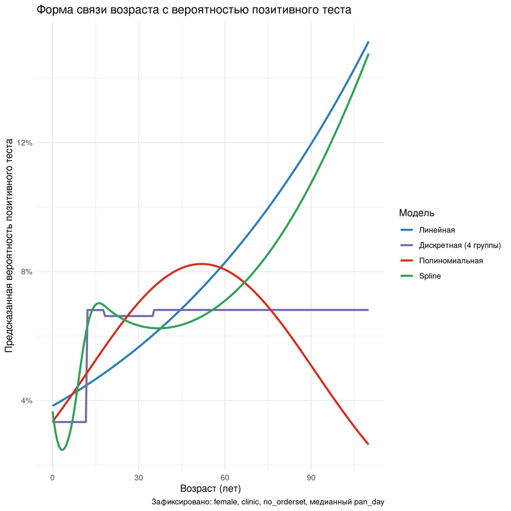

```r
age_grid <- tibble(
  age        = seq(0, 110, length.out = 200),
  gender     = factor("female",      levels = levels(df_logit$gender)),
  drive_thru = factor("clinic",      levels = levels(df_logit$drive_thru)),
  orderset   = factor("no_orderset", levels = levels(df_logit$orderset)),
  pan_day    = median(df_logit$pan_day),
  age_group4 = cut(seq(0, 110, length.out = 200),
                   breaks = c(0, 12, 18, 35, Inf),
                   labels = c("0–11", "12–17", "18–34", "35+"),
                   right  = FALSE,
                   include.lowest = TRUE)
) |>
  mutate(
    age_group4 = factor(age_group4, levels = levels(df_logit$age_group4)),
    linear     = predict(m_linear,   newdata = pick(everything()), type = "response"),
    discrete   = predict(m_discrete, newdata = pick(everything()), type = "response"),
    polynomial = predict(m_poly,     newdata = pick(everything()), type = "response"),
    spline     = predict(m_spline,   newdata = pick(everything()), type = "response")
  ) |>
  pivot_longer(c(linear, discrete, polynomial, spline),
               names_to = "model", values_to = "p_hat") |>
  mutate(model = factor(model,
                        levels = c("linear", "discrete", "polynomial", "spline"),
                        labels = c("Линейная", "Дискретная (4 группы)",
                                   "Полиномиальная", "Spline")))

ggplot(age_grid, aes(x = age, y = p_hat, colour = model)) +
  geom_line(linewidth = 1.1) +
  scale_y_continuous(labels = percent_format(accuracy = 1)) +
  scale_colour_manual(values = c("#2c7fb8", "#756bb1", "#d7301f", "#31a354")) +
  labs(
    x       = "Возраст (лет)",
    y       = "Предсказанная вероятность позитивного теста",
    colour  = "Модель",
    title   = "Форма связи возраста с вероятностью позитивного теста",
    caption = "Зафиксировано: female, clinic, no_orderset, медианный pan_day"
  ) +
  theme_minimal()
```

Для проверки формы связи возраста с исходом сравнены четыре спецификации: линейная, дискретная (4 группы: 0-11, 12-17, 18–34, 35+), полиномиальная (age^2) и natural spline (df=4). Сравнение по AIC показало что spline описывает данные лучше всего (AIC = 5791).

```r
anova(m_linear, m_spline, test = "Chisq")
```

| Resid. Df | Resid. Dev | Df | Deviance | Pr(>Chi) |
| --- | --- | --- | --- | --- |
| 13077 | 5828.732 | NA | NA | NA |
| 13074 | 5773.349 | 3 | 55.38353 | 0 |

Likelihood ratio test подтвердил что spline-модель значимо лучше линейной (χ^2=55.4, df=3, p < 0.001) - нелинейная спецификация возраста статистически обоснована.

```r
m_spline_interaction <- glm(
  positive ~ ns(age, df = 4) * orderset + gender + drive_thru + pan_day,
  data = df_logit, family = binomial()
)

anova(m_spline, m_spline_interaction, test = "Chisq")
```

| Resid. Df | Resid. Dev | Df | Deviance | Pr(>Chi) |
| --- | --- | --- | --- | --- |
| 13074 | 5773.349 | NA | NA | NA |
| 13070 | 5766.091 | 4 | 7.257798 | 0.1228759 |

Проверка взаимодействия age-orderset в spline-модели показала что добавление взаимодействия не улучшает подгонку значимо (χ^2=7.3, df=4, p = 0.12) - взаимодействие в финальную модель не включается.

Аналогично проверяем для pan_day

```r
m_spline_panday <- glm(
  positive ~ ns(age, df = 4) + gender + drive_thru + orderset + ns(pan_day, df = 3),
  data = df_logit, family = binomial()
)

anova(m_spline, m_spline_panday, test = "Chisq")
```

| Resid. Df | Resid. Dev | Df | Deviance | Pr(>Chi) |
| --- | --- | --- | --- | --- |
| 13074 | 5773.349 | NA | NA | NA |
| 13072 | 5762.906 | 2 | 10.44317 | 0.0053988 |

```r
tibble(
  model = c("Линейный pan_day", "Spline pan_day (df=3)"),
  aic   = c(AIC(m_spline), AIC(m_spline_panday))
)
```

| model | aic |
| --- | --- |
| Линейный pan_day | 5791.349 |
| Spline pan_day (df=3) | 5784.906 |

Проверка нелинейности pan_day показала что spline-спецификация с df=3 значимо лучше линейной (χ^2=10.4, df=2, p = 0.005, AIC = 5785 vs 5791) — день пандемии также включён в финальную модель через ns(pan_day, df=3).

## 6.4 Crude OR (одно-предикторные модели)

Сравнение с adjusted OR покажет, какие переменные конфаундируют.

```r
predictors <- c("gender", "drive_thru", "orderset")

crude_list <- list()
for (v in predictors) {
  fit <- glm(reformulate(v, "positive"), data = df_logit, family = binomial())
  crude_list[[v]] <- broom::tidy(fit, conf.int = TRUE, exponentiate = TRUE) |>
    filter(term != "(Intercept)") |>
    mutate(predictor = v)
}

crude_or <- bind_rows(crude_list) |>

  select(predictor, term, OR = estimate, conf.low, conf.high, p.value)
crude_or
```

| predictor | term | OR | conf.low | conf.high | p.value |
| --- | --- | --- | --- | --- | --- |
| gender | gendermale | 0.9192309 | 0.7948528 | 1.062739 | 0.2555180 |
| drive_thru | drive_thrudrive_thru | 1.1061783 | 0.9557735 | 1.281454 | 0.1771694 |
| orderset | ordersetorderset | 1.5747319 | 1.3099474 | 1.905970 | 0.0000020 |

В одно-предикторных моделях значимо ассоциированы с позитивным тестом `orderset` (OR = 1.575, p < 0.001); остальные предикторы незначимы. Возраст, pan_day исключён из таблицы crude OR - нелинейная спецификация (spline) не допускает интерпретации через единственный OR.

## 6.5 Adjusted OR (главная модель)

Теперь построим модель со всеми предикторами одновременно, чтобы понять какие ассоциации сохраняются после взаимного контроля-и не объясняются ли они друг другом.

```r
m_logit <- glm(
  positive ~ ns(age, df = 4) + gender + drive_thru + orderset + ns(pan_day, df = 3),
  data = df_logit, family = binomial()
)

adj_or <- broom::tidy(m_logit, conf.int = TRUE, exponentiate = TRUE) |>
  filter(term != "(Intercept)") |>
  filter(!str_detect(term, "ns\\(age")) |>
  filter(!str_detect(term, "ns\\(pan_day")) |>
  mutate(sig = if_else(p.value < 0.05, "p<0.05", "ns")) |>
  select(term, OR = estimate, conf.low, conf.high, p.value, sig)

adj_or
```

| term | OR | conf.low | conf.high | p.value | sig |
| --- | --- | --- | --- | --- | --- |
| gendermale | 0.9162596 | 0.7916396 | 1.060163 | 0.2403251 | ns |
| drive_thrudrive_thru | 0.9305089 | 0.7909223 | 1.095793 | 0.3863719 | ns |
| ordersetorderset | 1.4588084 | 1.2005036 | 1.783415 | 0.0001822 | p<0.05 |

После учёта нелинейности возраста через natural spline значимыми независимыми предикторами положительного теста оказались orderset (OR = 1.46, 95% CI: 1.20-1.79, p < 0.001); эффект возраста и дня пандемии интерпретируется через predicted probabilities ввиду нелинейной спецификации.

Проверяем, что оценка после поправки изменилась не более чем на 20%:

```r
comparison <- crude_or |>
  rename(OR_crude = OR, p_crude = p.value) |>
  inner_join(
    adj_or |> rename(OR_adj = OR, p_adj = p.value),
    by = "term"
  ) |>
  mutate(
    pct_change  = round(100 * (OR_adj - OR_crude) / OR_crude, 1),
    confounding = abs(pct_change) > 20
  ) |>
  select(term, OR_crude, OR_adj, pct_change, confounding)

comparison
```

| term | OR_crude | OR_adj | pct_change | confounding |
| --- | --- | --- | --- | --- |
| gendermale | 0.9192309 | 0.9162596 | -0.3 | FALSE |
| drive_thrudrive_thru | 1.1061783 | 0.9305089 | -15.9 | FALSE |
| ordersetorderset | 1.5747319 | 1.4588084 | -7.4 | FALSE |

## 6.6 Forest plot

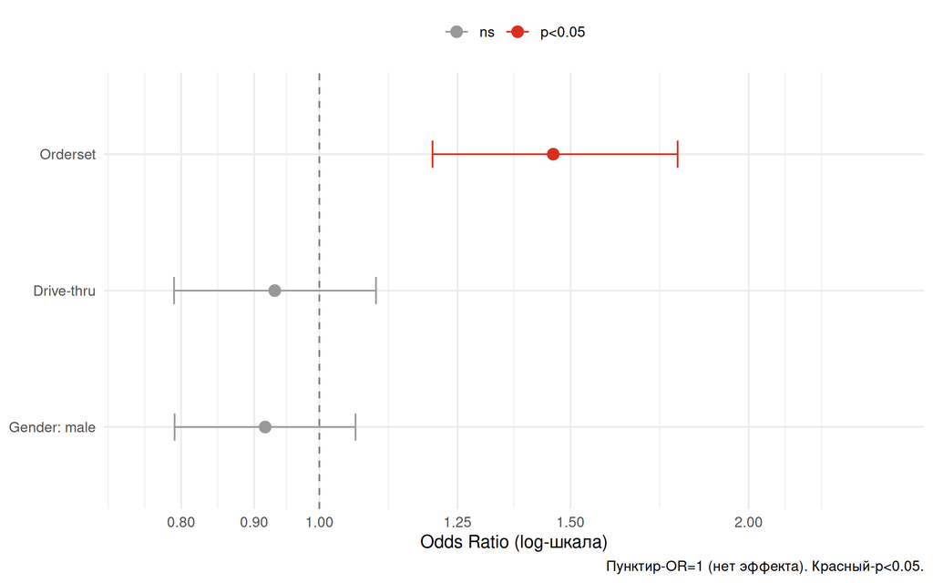

Adjusted OR (95% CI). Линия OR=1-нет эффекта

```r
adj_or |>
  mutate(
    term = case_when(
      term == "gendermale"           ~ "Gender: male",
      term == "drive_thrudrive_thru" ~ "Drive-thru",
      term == "ordersetorderset"     ~ "Orderset",
      TRUE ~ term
    )
  ) |>
  mutate(term = fct_reorder(term, OR)) |>
  ggplot(aes(OR, term, colour = sig)) +
  geom_vline(xintercept = 1, linetype = "dashed", colour = "grey50") +
  geom_point(size = 3) +
  geom_errorbarh(aes(xmin = conf.low, xmax = conf.high), height = 0.2) +
  scale_colour_manual(values = c("ns" = "grey60", "p<0.05" = "#d7301f"),
                      name = NULL) +
  scale_x_log10(limits = c(0.75, 2.5),
              breaks  = c(0.8, 0.9, 1.0, 1.25, 1.5, 2.0)) +
  labs(
    x = "Odds Ratio (log-шкала)",
    y = NULL,
    caption = "Пунктир-OR=1 (нет эффекта). Красный-p<0.05."
  ) +
  theme_minimal() +
  theme(legend.position = "top")
```

Forest plot наглядно показывает что из предикторов только orderset значимо ассоциирован с положительным тестом - его доверительный интервалы не пересекает линию OR=1. Orderset смещён вправо (OR=1.46) - протокол направления ассоциирован с более высокой позитивностью.

## 6.7 Predicted probabilities

```r
profiles <- expand_grid(
  age      = c(2, 10, 16, 25, 40, 70),
  orderset = factor(c("no_orderset", "orderset"),
                    levels = levels(df_logit$orderset))
) |>
  mutate(
    gender    = factor("female",  levels = levels(df_logit$gender)),
    drive_thru = factor("clinic", levels = levels(df_logit$drive_thru)),
    pan_day   = median(df_logit$pan_day)
  )

prof_pred <- predict(m_logit, newdata = profiles, type = "link", se.fit = TRUE)

profiles |>
  mutate(
    p_hat = round(plogis(prof_pred$fit), 4),
    lo    = round(plogis(prof_pred$fit - 1.96 * prof_pred$se.fit), 4),
    hi    = round(plogis(prof_pred$fit + 1.96 * prof_pred$se.fit), 4)
  ) |>
  select(age, orderset, p_hat, lo, hi)
```

| age | orderset | p_hat | lo | hi |
| --- | --- | --- | --- | --- |
| 2 | no_orderset | 0.0263 | 0.0207 | 0.0333 |
| 2 | orderset | 0.0379 | 0.0306 | 0.0467 |
| 10 | no_orderset | 0.0543 | 0.0437 | 0.0672 |
| 10 | orderset | 0.0772 | 0.0646 | 0.0921 |
| 16 | no_orderset | 0.0755 | 0.0603 | 0.0941 |
| 16 | orderset | 0.1064 | 0.0882 | 0.1278 |
| 25 | no_orderset | 0.0670 | 0.0535 | 0.0834 |
| 25 | orderset | 0.0948 | 0.0785 | 0.1140 |
| 40 | no_orderset | 0.0622 | 0.0479 | 0.0803 |
| 40 | orderset | 0.0882 | 0.0704 | 0.1099 |
| 70 | no_orderset | 0.0829 | 0.0599 | 0.1137 |
| 70 | orderset | 0.1165 | 0.0885 | 0.1520 |

```r
profiles_panday <- expand_grid(
  pan_day  = c(10, 30, 50, 70, 90, 107),
  orderset = factor(c("no_orderset", "orderset"),
                    levels = levels(df_logit$orderset))
) |>
  mutate(
    age        = median(df_logit$age),
    gender     = factor("female",  levels = levels(df_logit$gender)),
    drive_thru = factor("clinic",  levels = levels(df_logit$drive_thru))
  )

prof_pred2 <- predict(m_logit, newdata = profiles_panday, type = "link", se.fit = TRUE)

profiles_panday |>
  mutate(
    p_hat = round(plogis(prof_pred2$fit), 4),
    lo    = round(plogis(prof_pred2$fit - 1.96 * prof_pred2$se.fit), 4),
    hi    = round(plogis(prof_pred2$fit + 1.96 * prof_pred2$se.fit), 4)
  ) |>
  select(pan_day, orderset, p_hat, lo, hi)
```

| pan_day | orderset | p_hat | lo | hi |
| --- | --- | --- | --- | --- |
| 10 | no_orderset | 0.0471 | 0.0312 | 0.0706 |
| 10 | orderset | 0.0673 | 0.0457 | 0.0981 |
| 30 | no_orderset | 0.0676 | 0.0532 | 0.0857 |
| 30 | orderset | 0.0957 | 0.0781 | 0.1167 |
| 50 | no_orderset | 0.0683 | 0.0539 | 0.0860 |
| 50 | orderset | 0.0965 | 0.0792 | 0.1172 |
| 70 | no_orderset | 0.0486 | 0.0390 | 0.0604 |
| 70 | orderset | 0.0693 | 0.0577 | 0.0830 |
| 90 | no_orderset | 0.0403 | 0.0324 | 0.0501 |
| 90 | orderset | 0.0578 | 0.0481 | 0.0692 |
| 107 | no_orderset | 0.0428 | 0.0316 | 0.0578 |
| 107 | orderset | 0.0613 | 0.0465 | 0.0804 |

# 7 Проверка качества модели

```r
# ROC-AUC
roc_obj <- roc(df_logit$positive, fitted(m_logit))

cat("AUC:", round(auc(roc_obj), 3), "\n")
```

```
## AUC: 0.625
```

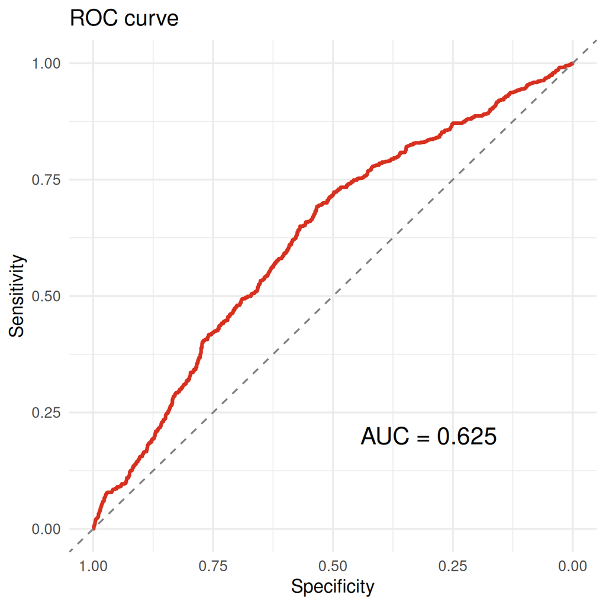

```r
# График ROC
ggroc(roc_obj, colour = "#d7301f", size = 1) +
  geom_abline(slope = 1, intercept = 1, linetype = "dashed", colour = "grey50") +
  annotate("text", x = 0.3, y = 0.2,
           label = sprintf("AUC = %.3f", auc(roc_obj)),
           size = 5) +
  labs(x = "Specificity", y = "Sensitivity",
       title = "ROC curve") +
  theme_minimal()
```

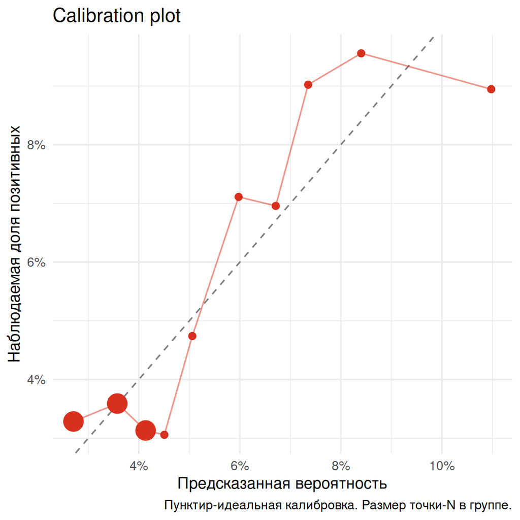

```r
cal_data <- df_logit |>
  mutate(
    pred   = fitted(m_logit),
    decile = ntile(pred, 10)
  ) |>
  group_by(decile) |>
  summarise(
    mean_pred     = mean(pred),
    mean_observed = mean(positive),
    n             = n()
  )

ggplot(cal_data, aes(x = mean_pred, y = mean_observed)) +
  geom_abline(slope = 1, intercept = 0,
              linetype = "dashed", colour = "grey50") +
  geom_point(aes(size = n), colour = "#d7301f") +
  geom_line(colour = "#d7301f", alpha = 0.5) +
  scale_size_continuous(range = c(2, 6), guide = "none") +
  scale_x_continuous(labels = scales::percent) +
  scale_y_continuous(labels = scales::percent) +
  labs(x = "Предсказанная вероятность",
       y = "Наблюдаемая доля позитивных",
       title = "Calibration plot",
       caption = "Пунктир-идеальная калибровка. Размер точки-N в группе.") +
  theme_minimal()
```

Calibration plot демонстрирует слабую калибровку-предсказанные вероятности сосредоточены в узком диапазоне (3-10%) и нестабильно соответствуют наблюдаемым значениям, что согласуется с низким AUC=0.625 и подтверждает что модель не предназначена для индивидуального предсказания риска.

# 8 Анализ чувствительности

```r
# Основная модель
# m_logit: 30-day filter, без demo_group, без patient_class, без payor_group
key_terms <- c("ordersetorderset")
# Sensitivity 1: только первый тест
df_sens1 <- raw |>
  filter(result %in% c("positive", "negative"),
         demo_group != "unidentified",
         age <= 110) |>
  arrange(subject_id, pan_day) |>
  distinct(subject_id, .keep_all = TRUE) |>  # первый тест
  mutate(
    positive   = as.integer(result == "positive"),
    gender     = factor(gender,       levels = c("female", "male")),
    drive_thru = factor(drive_thru_ind, levels = c(0,1),
                        labels = c("clinic","drive_thru")),
    orderset   = factor(orderset,     levels = c(0,1),
                        labels = c("no_orderset","orderset")),
    drive_thru = fct_relevel(drive_thru, "clinic"),
    orderset   = fct_relevel(orderset,   "no_orderset")
  )

m_sens1 <- glm(
  positive ~ ns(age, df=4) + gender + drive_thru + orderset + ns(pan_day, df=3),
  data = df_sens1, family = binomial()
)

# Sensitivity 2: добавляем demo_group
m_sens2 <- glm(
  positive ~ ns(age, df=4) + gender + drive_thru + orderset + ns(pan_day, df=3) + demo_group,
  data = df_logit, family = binomial()
)

# Sensitivity 3: только строки где patient_class не missing
df_sens3 <- df_logit |>
  filter(patient_class != "patient_class_missing") |>
  mutate(patient_class = fct_relevel(
    fct_drop(patient_class), "outpatient")
  )

m_sens3 <- glm(
  positive ~ ns(age, df=4) + gender + drive_thru + orderset + ns(pan_day, df=3) + patient_class,
  data = df_sens3, family = binomial()
)

# Sensitivity 4: + payor_group
df_sens4 <- df_logit |>
  filter(payor_group != "payor_group_missing") |>
  mutate(payor_group = fct_relevel(
    fct_drop(payor_group), "commercial")
  )

m_sens4 <- glm(
  positive ~ ns(age, df=4) + gender + drive_thru + orderset + ns(pan_day, df=3) + payor_group,
  data = df_sens4, family = binomial()
)

# Общее сравнение
bind_rows(
  broom::tidy(m_logit, exponentiate = TRUE, conf.int = TRUE) |> mutate(model = "Основная"),
  broom::tidy(m_sens1, exponentiate = TRUE, conf.int = TRUE) |> mutate(model = "Sens1: первый тест"),
  broom::tidy(m_sens2, exponentiate = TRUE, conf.int = TRUE) |> mutate(model = "Sens2: + demo_group"),
  broom::tidy(m_sens3, exponentiate = TRUE, conf.int = TRUE) |> mutate(model = "Sens3: + patient_class"),
  broom::tidy(m_sens4, exponentiate = TRUE, conf.int = TRUE) |> mutate(model = "Sens4: + payor_group")
) |>
  filter(term %in% key_terms) |>
  mutate(across(c(estimate, conf.low, conf.high), ~ round(.x, 3))) |>
  select(model, term, OR = estimate, conf.low, conf.high, p.value)
```

| model | term | OR | conf.low | conf.high | p.value |
| --- | --- | --- | --- | --- | --- |
| Основная | ordersetorderset | 1.459 | 1.201 | 1.783 | 0.0001822 |
| Sens1: первый тест | ordersetorderset | 1.410 | 1.154 | 1.734 | 0.0009182 |
| Sens2: + demo_group | ordersetorderset | 1.272 | 1.041 | 1.564 | 0.0203985 |
| Sens3: + patient_class | ordersetorderset | 1.660 | 1.109 | 2.541 | 0.0164143 |
| Sens4: + payor_group | ordersetorderset | 1.572 | 1.215 | 2.046 | 0.0006662 |

orderset остаётся значимым во всех пяти моделях — OR варьирует от 1.27 до 1.66, все p < 0.05.

# 9 Интерпретация результатов

**День пандемии:** также входит через spline - нелинейная связь с пиком позитивности в середине периода (~50-й день, 6.8–9.7%) и снижением к концу, что отражает расширение показаний к тестированию со временем.

**Orderset (стандартный протокол):** единственный предиктор с интерпретируемым OR = 1.46 (95% CI: 1.20–1.79, p < 0.001) — при наличии стандартизованного протокола направления шанс положительного теста выше в 1.5 раза при контроле возраста, пола, типа забора и дня пандемии. Важно: orderset скорее всего является маркером типа пациента - протокол направления применялся для определённых категорий пациентов с более высоким априорным риском, поэтому причинная интерпретация невозможна.

# 10 Ограничения

# 11 Вывод

Среди доступных предикторов orderset (OR = 1.46, 95% CI: 1.20–1.79) остаётся единственным предиктором с интерпретируемым OR; возраст и день пандемии значимо ассоциированы с исходом нелинейно и интерпретируются через predicted probabilities - абсолютная вероятность позитивного теста варьируется от 2.6% до 11.6% в зависимости от возраста и наличия протокола. Наблюдательный дизайн не позволяет делать причинные выводы, а модель описывает логистику тестирования, но не предназначена для индивидуального предсказания риска (AUC = 0.625).